# Covariate Creation

## Two Levels of Covariate Creation

**Level 1: From raw data to covariate**

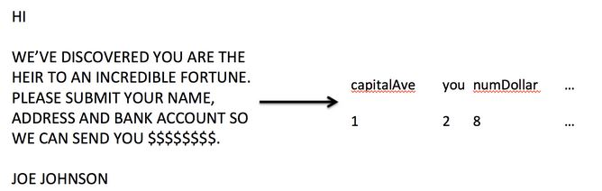

**Level 2: Transforming tidy covariates**

```r
library(kernlab)
data(spam)
spam$capitalAveSq <- spam$capitalAve^2
```

## Level 1: Raw Data -> Covariates

- Depends heavily on application
- The balancing act is summarization vs. information loss
- Examples
  - Text files: frequency of words, frequency of phrases ([Google ngrams](https://books.google.com/ngrams)), frequency of capital letters
  - Images: Edges, corners, blobs, ridges (computer vision feature detection
  - Webpages: Number and type of images, position of elements, colors, videos ([A/B Testing](https://en.wikipedia.org/wiki/A/B_testing))
  - People: Height, weight, hair color, sex, country of origin
- The more knowledge of the system you have the better the job you will do
- When in doubt, err on the side of more features
- Can be automated, but use caution!

## Level 2: Tidy Covariates -> New Covariates

- More necessary for some methods (regression, svms) than for others (classification trees)
- Should be done *only on the training set*
- The best approach is through exploratory analysis (plotting/tables)
- New covariates should be added to dataframes

## Load Example Data

```r
library(ISLR)
library(caret)
data(Wage)
inTrain <- createDataPartition(y=Wage$wage, p=0.7, list=F)
training <- Wage[inTrain,]
testing <- Wage[-inTrain,]
```

## Common Covariates to Add, Dummy Variables

**Basic idea – convert factor variables to indicator variables**

```r
table(training$jobclass)
```

```
 1. Industrial 2. Information
          1113            989
```

```r
dummies <- dummyVars(wage ~ jobclass, training)
head(predict(dummies, newdata=training))
```

```
       jobclass.1. Industrial jobclass.2. Information
231655                      1                       0
86582                       0                       1
161300                      1                       0
155159                      0                       1
376662                      0                       1
450601                      1                       0
```

## Removing Near-Zero Variance Covariates

```r
nsv <- nearZeroVar(training, saveMetrics=T)
nsv
```

```
           freqRatio percentUnique zeroVar   nzv
year        1.034783    0.33301618   FALSE FALSE
age         1.000000    2.90199810   FALSE FALSE
sex         0.000000    0.04757374    TRUE  TRUE
maritl      3.407407    0.23786870   FALSE FALSE
race        8.260664    0.19029496   FALSE FALSE
education   1.481720    0.23786870   FALSE FALSE
region      0.000000    0.04757374    TRUE  TRUE
jobclass    1.125379    0.09514748   FALSE FALSE
health      2.468647    0.09514748   FALSE FALSE
health_ins  2.243827    0.09514748   FALSE FALSE
logwage     1.144578   18.74405328   FALSE FALSE
wage        1.144578   18.74405328   FALSE FALSE
```

## Spline Basis

```r
library(splines)
bsBasis <- bs(training$age, df=3)
bsBasis
```

```
                  1            2            3
   [1,] 0.000000000 0.0000000000 0.000000e+00
   [2,] 0.236850055 0.0253767916 9.063140e-04
   [3,] 0.416337988 0.3211750193 8.258786e-02
   [4,] 0.430813836 0.2910904300 6.556091e-02
   [5,] 0.306334128 0.4241549461 1.957638e-01
   [6,] 0.424154946 0.3063341278 7.374710e-02
   [7,] 0.377630828 0.0906313987 7.250512e-03
   [8,] 0.440355309 0.2596967205 5.105149e-02
   [9,] 0.416337988 0.3211750193 8.258786e-02
  [10,] 0.433331375 0.1637029640 2.061445e-02
  [11,] 0.444358195 0.2275981001 3.885821e-02
  [12,] 0.362525595 0.3866939680 1.374912e-01
  [13,] 0.275519452 0.4362391326 2.302373e-01
  [14,] 0.442218287 0.1953987782 2.877966e-02
```

[output cut: 2098 more lines]

## Fitting Curves with Splines

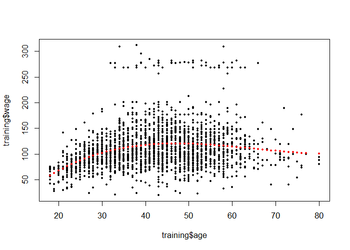

```r
lm1 <- lm(wage ~ bsBasis, training)
plot(training$age, training$wage, pch=19, cex=0.5)
points(training$age, predict(lm1, newdata=training), col="red", pch=19, cex=0.5)
```

## Splines on the Test Set

```r
predict(bsBasis, age=testing$age)
```

```
                  1            2            3
   [1,] 0.000000000 0.0000000000 0.000000e+00
   [2,] 0.236850055 0.0253767916 9.063140e-04
   [3,] 0.416337988 0.3211750193 8.258786e-02
   [4,] 0.430813836 0.2910904300 6.556091e-02
   [5,] 0.306334128 0.4241549461 1.957638e-01
   [6,] 0.424154946 0.3063341278 7.374710e-02
   [7,] 0.377630828 0.0906313987 7.250512e-03
   [8,] 0.440355309 0.2596967205 5.105149e-02
   [9,] 0.416337988 0.3211750193 8.258786e-02
  [10,] 0.433331375 0.1637029640 2.061445e-02
  [11,] 0.444358195 0.2275981001 3.885821e-02
  [12,] 0.362525595 0.3866939680 1.374912e-01
  [13,] 0.275519452 0.4362391326 2.302373e-01
  [14,] 0.442218287 0.1953987782 2.877966e-02
```

[output cut: 2098 more lines]

## Notes and Further Reading

- Level 1 feature creation (raw data to covariates)
  - Science is key. Google “feature extraction for [data type]”
  - Err on overcreation of features
  - In some applications (images, voices) automated feature creation is possible/necessary
  - http://www.cs.nyu.edu/~yann/talks/lecun-ranzato-icml2013.pdf
- Level 2 feature creation (covariates to new covariates)
  - The function `preProcess` in `caret` will handle some preprocessing
  - Create new covariates if you think they will improve fit
  - Use exploratory analysis on the training set for creating them
  - Be careful about overfitting!
- [Preprocessing with caret](https://topepo.github.io/caret/preprocess.html)
- If you want to fit spline models, use the `gam` method in the `caret` package which allows smoothing of multiple variables
- More on feature creation/data tidying in the Obtaining Data course from the Data Science course specialization